# Health-Related Social Influence Strategies in Overweight Romantic Couples: Daily Associations with Physical Activity and Affect for Targets and Actors

Pascal Küng, MSc (ORCID: 0000-0001-7346-9414), Corina Berli, PhD (ORCID: 0000-0002-5078-3539), Patrick S. Höhener, MSc (ORCID: 0000-0003-3635-2799), Robert Tobias, PhD (ORCID: 0000-0001-7972-122X), Urte Scholz, PhD (ORCID: 0000-0003-0184-5921)

2024-09-28

# Setup and loading

```r
# load packages

library(ggplot2)
library(nlme)
library(MASS)
library(haven)
library(scales)
library(cowplot)
library(devtools)
library(ggResidpanel)
library(glmmTMB)
library(DHARMa)
library(ggeffects)
library(broom.mixed)
library(easystats)
library(Hmisc)
library(bmlm)
library(tidyverse)
library(wbCorr)
# Date of diary days
range(df$sbwdat01, na.rm = T)
```

```
## [1]  Inf -Inf
```

## Introducing Lagged Variables

```r
df <- df %>%
  group_by(CoupleID) %>%
  mutate(
    pbwmvpa01_next_day = Lag(pbwmvpa01, -1),
    Paff_target_next_day = Lag(Paff_target, -1),
    Naff_target_next_day = Lag(Naff_target, -1),

    sbwmvpa01_next_day = Lag(sbwmvpa01, -1),
    Paff_agent_next_day = Lag(Paff_agent, -1),
    Naff_agent_next_day = Lag(Naff_agent, -1)
  ) %>%
  ungroup()

# Check if it is correct
head(df[ , c("CoupleID", "pbwmvpa01", "pbwmvpa01_next_day")])
```

| CoupleID | pbwmvpa01 | pbwmvpa01_next_day |
| --- | --- | --- |
| 1 | 40 | 27 |
| 1 | 27 | 56 |
| 1 | 56 | 76 |
| 1 | 76 | 16 |
| 1 | 16 | 51 |
| 1 | 51 | NA |

# Modelling

We define the following functions to facilitate reporting of the models.

```r
# Defining common elements
common_within_person_effects <- c(
  '(Intercept)',
  '---WITHIN-PERSON EFFECTS---',
  'PSC_agent_cw',
  'NSC_agent_cw',
  'sbyday',
  'weeknd2',
  'weartime_cw'
)

common_between_person_effects <- c(
  'PSC_agent_cb',
  'NSC_agent_cb',
  'weartime_cb',
  '---PREVIOUS-DAY OUTCOMES---',
  'Paff_agent',
  'Paff_target',
  'Naff_agent',
  'Naff_target',
  'pbwmvpa01',
  'sbwmvpa01'
)

common_random_effects <- c(
  'Std.Dev.(Intercept)|CoupleID',
  'Std.Dev.PSC_agent_cw|CoupleID',
  'Std.Dev.NSC_agent_cw|CoupleID',
  'Cor.PSC_agent_cw.(Intercept)|CoupleID',
  'Cor.NSC_agent_cw.(Intercept)|CoupleID',
  'Cor.NSC_agent_cw.PSC_agent_cw|CoupleID'
)

common_model_info <- c(
  'Within-group standard error',
  'dispersion',
  'AR1'
)

# Order for report
order_rep <- c(
  common_within_person_effects,
  '---BETWEEN-PERSON EFFECTS---',
  common_between_person_effects,
  '---RANDOM-EFFECTS---',
  common_random_effects,
  '---------MODEL INFO---------',
  common_model_info
)



full_report <- function(model, order) {
  if (class(model) == 'glmmTMB') {
    return(report_glmmTMB(model, order))
  } else {
    return(report_nlme(model, order))
  }
}


report_glmmTMB <- function(model, order) {
  # Extracting model parameters and creating the initial dataframe
  rep_df <- as.data.frame(model_parameters(model, exponentiate = TRUE))[,c('Parameter', 'Coefficient', 'SE', 'p', 'CI_low', 'CI_high', 'Effects', 'Component')]

  # Removing rows where the Parameter includes 'factor'
  rep_df <- rep_df[rep_df$Effects != 'random',]


  # Adding confidence intervals

  int <- as.data.frame(confint(model))

  intt <- int[!grepl('factor', rownames(int)),]
  intervals <- intt[grepl('CoupleID', rownames(intt)),]


  df_intervals <- data.frame('Parameter' = rownames(intervals),
                             'Coefficient' = intervals$Estimate,
                             'SE' = NA,
                             'CI_low' = intervals$`2.5 %`,
                             'CI_high' = intervals$`97.5 %`,
                             'p' = NA,
                             'Effects' = 'random',
                             'Component' = 'conditional')

  rep_df <- rbind(rep_df, df_intervals)


  # Extracting the AR1 coefficient from the model
  ar1 <- capture.output(summary(model)$varcor)
  if (length(grep("ar1", ar1)) > 0) {
    ar1_value <- as.numeric(strsplit(ar1[grep("ar1", ar1)], "\\(ar1\\)")[[1]][2])
  } else {
    ar1_value <- NA
  }


  # Combining and reporting

  rep_df <- rep_df %>%
    add_row(Parameter = '---WITHIN-PERSON EFFECTS---') %>%
    add_row(Parameter = '---BETWEEN-PERSON EFFECTS---') %>%
    add_row(Parameter = '---RANDOM-EFFECTS---') %>%
    add_row(Parameter = 'Within-group standard error') %>%
    add_row(Parameter = '---------MODEL INFO---------') %>%
    add_row(Parameter = 'AR1', Coefficient = ar1_value)

  rep_df
  rep_df[rep_df$Component == 'dispersion' & rep_df$Parameter == '(Intercept)', ]$Parameter <- 'dispersion'


  # Reorder the dataframe based on 'order'
  rep_df$Parameter[rep_df$Parameter == "sbwwear_cw"] <- 'weartime_cw'
  rep_df$Parameter[rep_df$Parameter == "sbwwear_cb"] <- 'weartime_cb'
  rep_df$Parameter[rep_df$Parameter == "pbwwear_cw"] <- 'weartime_cw'
  rep_df$Parameter[rep_df$Parameter == "pbwwear_cb"] <- 'weartime_cb'


  rep_df <- rep_df[match(order, rep_df$Parameter),]

  # Call function for rounding and adding stars
  rep_df <- process_coefficients(rep_df)


  return(rep_df)
}



report_nlme <- function(model, order) {
  # Extracting fixed effects
  rep_df <- as.data.frame(model_parameters(model))[,c('Parameter', 'Coefficient', 'SE', 'p', 'CI_low', 'CI_high', 'Effects')]

  rep_df <- tryCatch({

      # Confidence intervals of random effects
      int <- intervals(model)
      int_rand <- as.data.frame(int$reStruct)

      # add AR1
      int_ar1 <- as.data.frame(int$corStruct)

      if (nrow(int_ar1) > 0) {
        rownames(int_ar1) <- c('AR1')
        colnames(int_ar1) <- colnames(int_rand)
        int_rand <- rbind(int_rand, int_ar1)
      } else {
        # Create a row with NA values
        na_row <- setNames(data.frame(matrix(NA, ncol = ncol(int_rand), nrow = 1)), colnames(int_rand))
        rownames(na_row) <- 'AR1'
        int_rand <- rbind(int_rand, na_row)
      }

      # Add Confint for sigma
      int_resid <- as.data.frame(int$sigma)

      int_rand[nrow(int_rand) + 1,] <- c(int_resid[1, 1], int_resid[2, 1], int_resid[3, 1])
      rownames(int_rand)[nrow(int_rand)] <- 'Within-group standard error'




      # Construct df

      int_df <- data.frame(
        Parameter = rownames(int_rand),
        Coefficient = int_rand$CoupleID.est.,
        SE = NA,
        CI_low = int_rand$CoupleID.lower,
        CI_high = int_rand$CoupleID.upper,
        p = NA,
        Effects = 'random'
      )

      # Combine
      rep_df <- rep_df[rep_df$Effects != 'random',]

      rep_df <- rbind(rep_df, int_df)
      rep_df$Parameter[rep_df$Parameter == 'sd((Intercept))'] <- 'Std.Dev.(Intercept)|CoupleID'
      rep_df$Parameter[rep_df$Parameter == 'sd(PSC_agent_cw)'] <- 'Std.Dev.PSC_agent_cw|CoupleID'
      rep_df$Parameter[rep_df$Parameter == 'sd(NSC_agent_cw)'] <- 'Std.Dev.NSC_agent_cw|CoupleID'
      rep_df$Parameter[rep_df$Parameter == 'cor((Intercept),PSC_agent_cw)'] <- 'Cor.PSC_agent_cw.(Intercept)|CoupleID'
      rep_df$Parameter[rep_df$Parameter == 'cor((Intercept),NSC_agent_cw)'] <- 'Cor.NSC_agent_cw.(Intercept)|CoupleID'
      rep_df$Parameter[rep_df$Parameter == 'cor(PSC_agent_cw,NSC_agent_cw)'] <- 'Cor.NSC_agent_cw.PSC_agent_cw|CoupleID'
      rep_df$Parameter[rep_df$Parameter == 'cor(NSC_agent_cw,PSC_agent_cw)'] <- 'Cor.NSC_agent_cw.PSC_agent_cw|CoupleID'
      rep_df
    }, error = function(e) {
      rep_df$Parameter[rep_df$Parameter == "SD (Intercept)"] <- 'Std.Dev.(Intercept)|CoupleID'
      rep_df$Parameter[rep_df$Parameter == 'SD (PSC_agent_cw)'] <- 'Std.Dev.PSC_agent_cw|CoupleID'
      rep_df$Parameter[rep_df$Parameter == 'SD (NSC_agent_cw)'] <- 'Std.Dev.NSC_agent_cw|CoupleID'
      rep_df$Parameter[rep_df$Parameter == 'Cor (Intercept~PSC_agent_cw)'] <- 'Cor.PSC_agent_cw.(Intercept)|CoupleID'
      rep_df$Parameter[rep_df$Parameter == 'Cor (Intercept~NSC_agent_cw)'] <- 'Cor.NSC_agent_cw.(Intercept)|CoupleID'
      rep_df$Parameter[rep_df$Parameter == 'Cor (PSC_agent_cw~NSC_agent_cw)'] <- 'Cor.NSC_agent_cw.PSC_agent_cw|CoupleID'
      rep_df$Parameter[rep_df$Parameter == 'Cor (NSC_agent_cw~PSC_agent_cw)'] <- 'Cor.NSC_agent_cw.PSC_agent_cw|CoupleID'
      rep_df$Parameter[rep_df$Parameter == 'SD (Observations)'] <- 'Within-group standard error'
      rep_df
    }
  )

  # Finishing touches
  rep_df <- rep_df %>%
    add_row(Parameter = '---WITHIN-PERSON EFFECTS---') %>%
    add_row(Parameter = '---BETWEEN-PERSON EFFECTS---') %>%
    add_row(Parameter = '---RANDOM-EFFECTS---') %>%
    add_row(Parameter = '---------MODEL INFO---------') %>%
    add_row(Parameter = 'dispersion') %>%
    add_row(Parameter = 'sbwwear_cb') %>%
    add_row(Parameter = 'sbwwear_cw')


  # Reorder the dataframe based on 'order'
  rep_df <- rep_df[match(order, rep_df$Parameter),]

  # Call function for rounding and adding stars
  rep_df <- process_coefficients(rep_df)

  return(rep_df)
}





process_coefficients <- function(df) {
  # Round
  df[, c(2, 3, 5, 6)] <- round(df[, c(2, 3, 5, 6)], 2)
  df[, 4] <- round(df[, 4], 3)

  # Add stars
  df$Coefficient <- as.character(sprintf("%.2f", df$Coefficient))
  df$Coefficient <- ifelse(is.na(df$p), df$Coefficient,
                           ifelse(df$p < 0.001, paste0(df$Coefficient, "***"),
                                  ifelse(df$p < 0.01, paste0(df$Coefficient, "**"),
                                         ifelse(df$p < 0.05, paste0(df$Coefficient, "*"),
                                                df$Coefficient))))
  return(df)
}
```

## Lagged Models

### Lagged Models for TARGET

#### Positive Affect - Target

```r
posaff_target_lagged <- lme(
    fixed = Paff_target_next_day ~
        Paff_target +
        PSC_agent_cw + NSC_agent_cw +
        sbyday + weeknd2 +
        PSC_agent_cb + NSC_agent_cb,
    data = as.data.frame(df),
    random = ~ PSC_agent_cw + NSC_agent_cw | CoupleID,
    correlation = corAR1(form = ~ 1 | CoupleID),
    na.action = na.omit,
    control = lmeControl(opt='optim',
                         maxIter = 1e4,
                         msMaxEval = 1e4)
)

check_singularity(posaff_target_lagged)
```

```
## [1] FALSE
```

```r
check_model(posaff_target_lagged)
```

```
## Converting missing values (`NA`) into regular values currently not
##   possible for variables of class `NULL`.
```

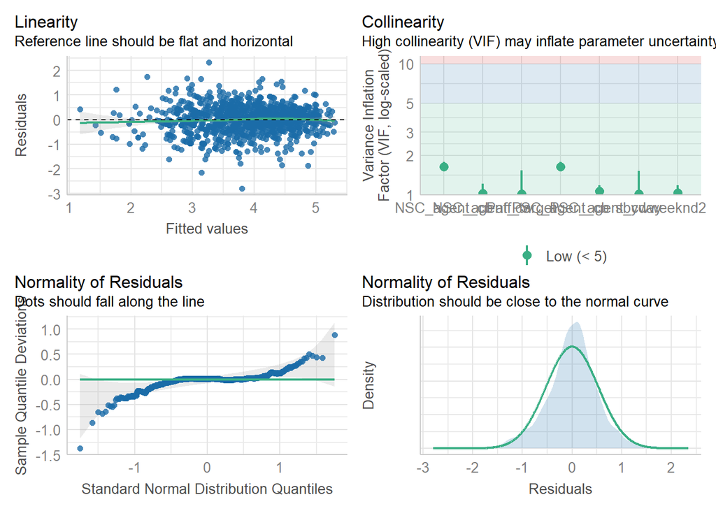

```r
posaff_target_lagged_rep <- full_report(posaff_target_lagged, order_rep)
posaff_target_lagged_rep
```

|  | Parameter | Coefficient | SE | p | CI_low | CI_high | Effects |
| --- | --- | --- | --- | --- | --- | --- | --- |
| 1 | (Intercept) | 2.65*** | 0.12 | 0.000 | 2.41 | 2.89 | fixed |
| 17 | —WITHIN-PERSON EFFECTS— | NA | NA | NA | NA | NA | NA |
| 3 | PSC_agent_cw | -0.08 | 0.06 | 0.240 | -0.20 | 0.05 | fixed |
| 4 | NSC_agent_cw | -0.06 | 0.11 | 0.610 | -0.28 | 0.16 | fixed |
| 5 | sbyday | -0.01** | 0.00 | 0.001 | -0.02 | -0.01 | fixed |
| 6 | weeknd2 | 0.00 | 0.04 | 0.974 | -0.07 | 0.08 | fixed |
| NA | NA | NA | NA | NA | NA | NA | NA |
| 18 | —BETWEEN-PERSON EFFECTS— | NA | NA | NA | NA | NA | NA |
| 7 | PSC_agent_cb | 0.34* | 0.17 | 0.046 | 0.01 | 0.67 | fixed |
| 8 | NSC_agent_cb | -0.54 | 0.32 | 0.090 | -1.18 | 0.09 | fixed |
| NA.1 | NA | NA | NA | NA | NA | NA | NA |
| NA.2 | NA | NA | NA | NA | NA | NA | NA |
| NA.3 | NA | NA | NA | NA | NA | NA | NA |
| 2 | Paff_target | 0.35*** | 0.03 | 0.000 | 0.29 | 0.40 | fixed |
| NA.4 | NA | NA | NA | NA | NA | NA | NA |
| NA.5 | NA | NA | NA | NA | NA | NA | NA |
| NA.6 | NA | NA | NA | NA | NA | NA | NA |
| NA.7 | NA | NA | NA | NA | NA | NA | NA |
| 19 | —RANDOM-EFFECTS— | NA | NA | NA | NA | NA | NA |
| 9 | Std.Dev.(Intercept)\|CoupleID | 0.43 | NA | NA | 0.33 | 0.56 | random |
| 10 | Std.Dev.PSC_agent_cw\|CoupleID | 0.24 | NA | NA | 0.12 | 0.50 | random |
| 11 | Std.Dev.NSC_agent_cw\|CoupleID | 0.19 | NA | NA | 0.03 | 1.29 | random |
| 12 | Cor.PSC_agent_cw.(Intercept)\|CoupleID | 0.08 | NA | NA | -0.65 | 0.74 | random |
| 13 | Cor.NSC_agent_cw.(Intercept)\|CoupleID | 0.21 | NA | NA | -0.93 | 0.97 | random |
| 14 | Cor.NSC_agent_cw.PSC_agent_cw\|CoupleID | 0.89 | NA | NA | -1.00 | 1.00 | random |
| 20 | ———MODEL INFO——— | NA | NA | NA | NA | NA | NA |
| 16 | Within-group standard error | 0.55 | NA | NA | 0.53 | 0.58 | random |
| 21 | dispersion | NA | NA | NA | NA | NA | NA |
| 15 | AR1 | -0.07 | NA | NA | -0.19 | 0.05 | random |

```r
# prepare to save to excel
all_models <- list(posaff_target_lagged_rep = posaff_target_lagged_rep)
```

#### Negative Affect - Target

```r
### Base model for negative affect target
negaff_target_lagged <- lme(
  fixed = Naff_target_next_day ~
        Naff_target +
        PSC_agent_cw + NSC_agent_cw +
        sbyday + weeknd2 +
        PSC_agent_cb + NSC_agent_cb,
  data = as.data.frame(df),
  random = ~ 1 | CoupleID,
  #correlation = corAR1(form = ~ 1 | CoupleID),
  na.action = na.omit,
  control = lmeControl(opt='optim',
                         maxIter = 1e4,
                         msMaxEval = 1e4)
)

check_singularity(negaff_target_lagged)
```

```
## [1] FALSE
```

```r
check_model(negaff_target_lagged)
```

```
## Converting missing values (`NA`) into regular values currently not
##   possible for variables of class `NULL`.
```

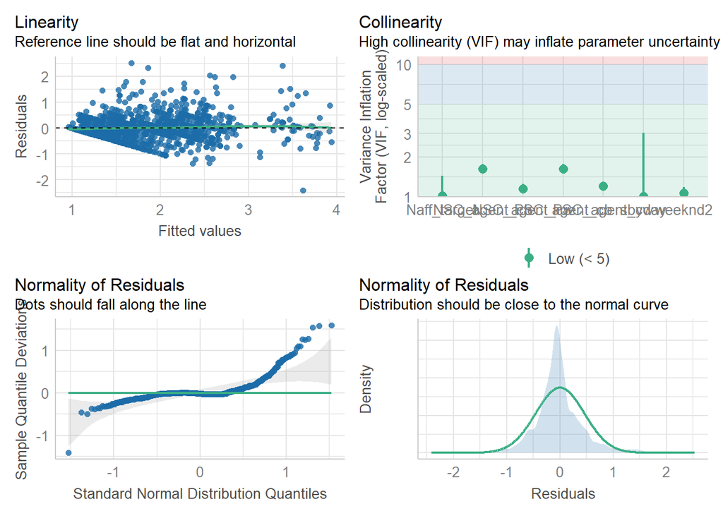

```r
negaff_target_lagged_rep <- full_report(negaff_target_lagged, order=order_rep)
negaff_target_lagged_rep
```

|  | Parameter | Coefficient | SE | p | CI_low | CI_high | Effects |
| --- | --- | --- | --- | --- | --- | --- | --- |
| 1 | (Intercept) | 1.44*** | 0.08 | 0.000 | 1.28 | 1.60 | fixed |
| 12 | —WITHIN-PERSON EFFECTS— | NA | NA | NA | NA | NA | NA |
| 3 | PSC_agent_cw | -0.02 | 0.05 | 0.741 | -0.11 | 0.08 | fixed |
| 4 | NSC_agent_cw | 0.10 | 0.08 | 0.227 | -0.06 | 0.26 | fixed |
| 5 | sbyday | 0.00 | 0.00 | 0.232 | 0.00 | 0.01 | fixed |
| 6 | weeknd2 | -0.02 | 0.03 | 0.518 | -0.09 | 0.04 | fixed |
| NA | NA | NA | NA | NA | NA | NA | NA |
| 13 | —BETWEEN-PERSON EFFECTS— | NA | NA | NA | NA | NA | NA |
| 7 | PSC_agent_cb | -0.28 | 0.19 | 0.137 | -0.65 | 0.09 | fixed |
| 8 | NSC_agent_cb | 0.36 | 0.36 | 0.315 | -0.35 | 1.06 | fixed |
| NA.1 | NA | NA | NA | NA | NA | NA | NA |
| NA.2 | NA | NA | NA | NA | NA | NA | NA |
| NA.3 | NA | NA | NA | NA | NA | NA | NA |
| NA.4 | NA | NA | NA | NA | NA | NA | NA |
| NA.5 | NA | NA | NA | NA | NA | NA | NA |
| 2 | Naff_target | 0.19*** | 0.03 | 0.000 | 0.13 | 0.25 | fixed |
| NA.6 | NA | NA | NA | NA | NA | NA | NA |
| NA.7 | NA | NA | NA | NA | NA | NA | NA |
| 14 | —RANDOM-EFFECTS— | NA | NA | NA | NA | NA | NA |
| 9 | Std.Dev.(Intercept)\|CoupleID | 0.49 | NA | NA | 0.41 | 0.59 | random |
| NA.8 | NA | NA | NA | NA | NA | NA | NA |
| NA.9 | NA | NA | NA | NA | NA | NA | NA |
| NA.10 | NA | NA | NA | NA | NA | NA | NA |
| NA.11 | NA | NA | NA | NA | NA | NA | NA |
| NA.12 | NA | NA | NA | NA | NA | NA | NA |
| 15 | ———MODEL INFO——— | NA | NA | NA | NA | NA | NA |
| 11 | Within-group standard error | 0.48 | NA | NA | 0.46 | 0.50 | random |
| 16 | dispersion | NA | NA | NA | NA | NA | NA |
| 10 | AR1 | NA | NA | NA | NA | NA | random |

```r
# Add to list
all_models[['negaff_target_lagged_rep']] <- negaff_target_lagged_rep
```

#### MVPA - Target

```r
mvpa_target_lagged <- glmmTMB(
  sbwmvpa01_next_day ~
    sbwmvpa01 +
    PSC_agent_cw + NSC_agent_cw +
    sbyday + weeknd2 +
    PSC_agent_cb + NSC_agent_cb +
    sbwwear_cw + sbwwear_cb +

    (1 | CoupleID),
    family = nbinom1,
    data = df,
    control = glmmTMBControl(optArgs = list(iter.max = 1e4, eval.max = 1e4))
)
check_singularity(mvpa_target_lagged)
```

```
## [1] FALSE
```

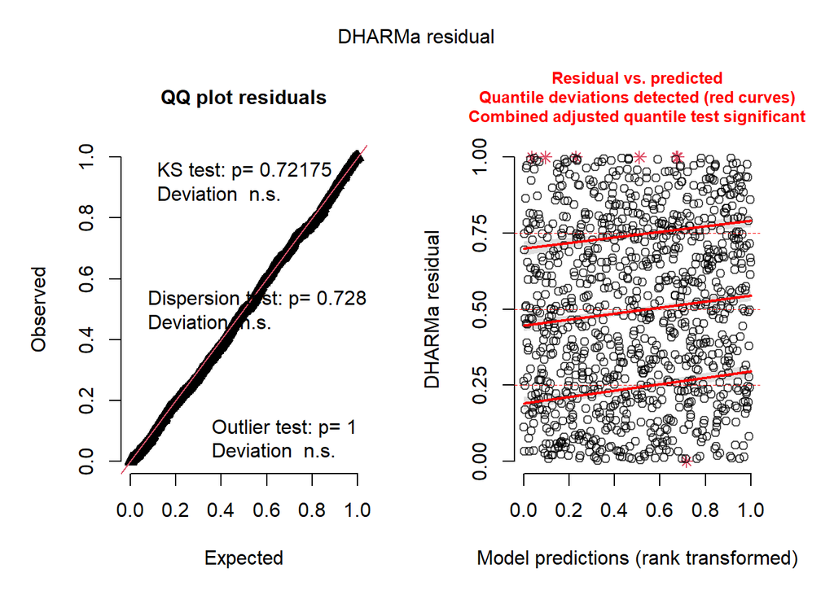

```r
simResids <- simulateResiduals(mvpa_target_lagged, nSim=1005)
plot(simResids)
```

```r
mvpa_target_lagged_rep <- full_report(mvpa_target_lagged, order_rep)
mvpa_target_lagged_rep
```

|  | Parameter | Coefficient | SE | p | CI_low | CI_high | Effects | Component |
| --- | --- | --- | --- | --- | --- | --- | --- | --- |
| 1 | (Intercept) | 41.85*** | 2.87 | 0.000 | 36.59 | 47.86 | fixed | conditional |
| 13 | —WITHIN-PERSON EFFECTS— | NA | NA | NA | NA | NA | NA | NA |
| 3 | PSC_agent_cw | 1.04 | 0.06 | 0.462 | 0.93 | 1.17 | fixed | conditional |
| 4 | NSC_agent_cw | 0.86 | 0.09 | 0.133 | 0.70 | 1.05 | fixed | conditional |
| 5 | sbyday | 1.01 | 0.00 | 0.221 | 1.00 | 1.02 | fixed | conditional |
| 6 | weeknd2 | 0.96 | 0.04 | 0.290 | 0.88 | 1.04 | fixed | conditional |
| 9 | weartime_cw | 0.97* | 0.01 | 0.014 | 0.95 | 0.99 | fixed | conditional |
| 14 | —BETWEEN-PERSON EFFECTS— | NA | NA | NA | NA | NA | NA | NA |
| 7 | PSC_agent_cb | 1.04 | 0.18 | 0.814 | 0.74 | 1.46 | fixed | conditional |
| 8 | NSC_agent_cb | 1.19 | 0.41 | 0.602 | 0.61 | 2.33 | fixed | conditional |
| 10 | weartime_cb | 1.00 | 0.03 | 0.870 | 0.95 | 1.07 | fixed | conditional |
| NA | NA | NA | NA | NA | NA | NA | NA | NA |
| NA.1 | NA | NA | NA | NA | NA | NA | NA | NA |
| NA.2 | NA | NA | NA | NA | NA | NA | NA | NA |
| NA.3 | NA | NA | NA | NA | NA | NA | NA | NA |
| NA.4 | NA | NA | NA | NA | NA | NA | NA | NA |
| NA.5 | NA | NA | NA | NA | NA | NA | NA | NA |
| 2 | sbwmvpa01 | 1.00 | 0.00 | 0.363 | 1.00 | 1.00 | fixed | conditional |
| 15 | —RANDOM-EFFECTS— | NA | NA | NA | NA | NA | NA | NA |
| 12 | Std.Dev.(Intercept)\|CoupleID | 0.44 | NA | NA | 0.36 | 0.53 | random | conditional |
| NA.6 | NA | NA | NA | NA | NA | NA | NA | NA |
| NA.7 | NA | NA | NA | NA | NA | NA | NA | NA |
| NA.8 | NA | NA | NA | NA | NA | NA | NA | NA |
| NA.9 | NA | NA | NA | NA | NA | NA | NA | NA |
| NA.10 | NA | NA | NA | NA | NA | NA | NA | NA |
| 17 | ———MODEL INFO——— | NA | NA | NA | NA | NA | NA | NA |
| 16 | Within-group standard error | NA | NA | NA | NA | NA | NA | NA |
| 11 | dispersion | 16.46 | NA | NA | 14.83 | 18.27 | fixed | dispersion |
| 18 | AR1 | NA | NA | NA | NA | NA | NA | NA |

```r
# extend list

all_models[['mvpa_target_lagged_rep']] <- mvpa_target_lagged_rep
```

Note, that fixed effects and their CI have been exponentiated, representing now odds ratios. SE have been scaled. Random effects are still on the log-scale and represent the variability.

### Lagged Models for AGENT

How is the use of persuasion and pressure associated with outcomes in the user?

#### Positive affect - Agent

```r
posaff_agent_lagged <- lme(
  fixed = Paff_agent_next_day ~
        Paff_agent +
        PSC_agent_cw + NSC_agent_cw +
        sbyday + weeknd2 +
        PSC_agent_cb + NSC_agent_cb,
  data = as.data.frame(df),
  random = ~ 1 | CoupleID,
  correlation = corAR1(form = ~ 1 | CoupleID),
  na.action = na.omit,
  control = lmeControl(opt='optim',
                      maxIter = 1e4,
                      msMaxEval = 1e4)
)
check_singularity(posaff_agent_lagged)
```

```
## [1] FALSE
```

```r
check_model(posaff_agent_lagged)
```

```
## Converting missing values (`NA`) into regular values currently not
##   possible for variables of class `NULL`.
```

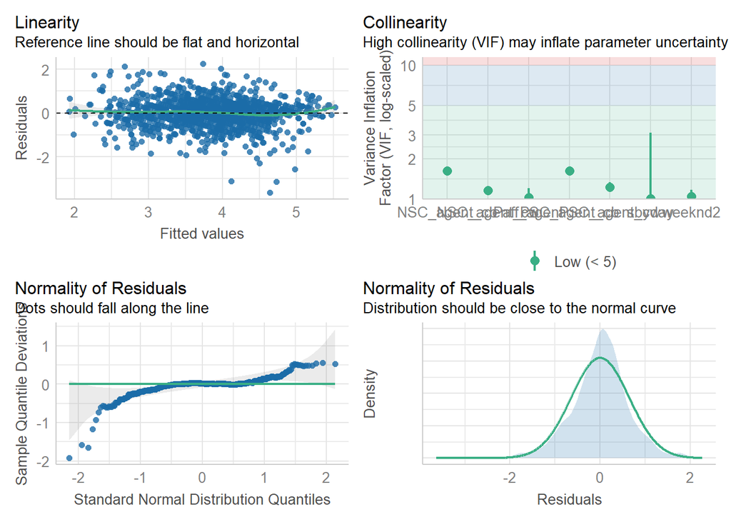

```r
posaff_agent_lagged_rep <- full_report(posaff_agent_lagged,order=order_rep)
posaff_agent_lagged_rep
```

|  | Parameter | Coefficient | SE | p | CI_low | CI_high | Effects |
| --- | --- | --- | --- | --- | --- | --- | --- |
| 1 | (Intercept) | 2.02*** | 0.11 | 0.000 | 1.81 | 2.24 | fixed |
| 12 | —WITHIN-PERSON EFFECTS— | NA | NA | NA | NA | NA | NA |
| 3 | PSC_agent_cw | -0.06 | 0.06 | 0.323 | -0.18 | 0.06 | fixed |
| 4 | NSC_agent_cw | 0.02 | 0.10 | 0.839 | -0.18 | 0.22 | fixed |
| 5 | sbyday | -0.00 | 0.00 | 0.321 | -0.01 | 0.00 | fixed |
| 6 | weeknd2 | 0.04 | 0.04 | 0.362 | -0.04 | 0.11 | fixed |
| NA | NA | NA | NA | NA | NA | NA | NA |
| 13 | —BETWEEN-PERSON EFFECTS— | NA | NA | NA | NA | NA | NA |
| 7 | PSC_agent_cb | 0.08 | 0.12 | 0.526 | -0.16 | 0.32 | fixed |
| 8 | NSC_agent_cb | 0.04 | 0.23 | 0.848 | -0.42 | 0.51 | fixed |
| NA.1 | NA | NA | NA | NA | NA | NA | NA |
| NA.2 | NA | NA | NA | NA | NA | NA | NA |
| 2 | Paff_agent | 0.48*** | 0.03 | 0.000 | 0.43 | 0.53 | fixed |
| NA.3 | NA | NA | NA | NA | NA | NA | NA |
| NA.4 | NA | NA | NA | NA | NA | NA | NA |
| NA.5 | NA | NA | NA | NA | NA | NA | NA |
| NA.6 | NA | NA | NA | NA | NA | NA | NA |
| NA.7 | NA | NA | NA | NA | NA | NA | NA |
| 14 | —RANDOM-EFFECTS— | NA | NA | NA | NA | NA | NA |
| 9 | Std.Dev.(Intercept)\|CoupleID | 0.30 | NA | NA | 0.22 | 0.43 | random |
| NA.8 | NA | NA | NA | NA | NA | NA | NA |
| NA.9 | NA | NA | NA | NA | NA | NA | NA |
| NA.10 | NA | NA | NA | NA | NA | NA | NA |
| NA.11 | NA | NA | NA | NA | NA | NA | NA |
| NA.12 | NA | NA | NA | NA | NA | NA | NA |
| 15 | ———MODEL INFO——— | NA | NA | NA | NA | NA | NA |
| 11 | Within-group standard error | 0.66 | NA | NA | 0.62 | 0.70 | random |
| 16 | dispersion | NA | NA | NA | NA | NA | NA |
| 10 | AR1 | -0.25 | NA | NA | -0.35 | -0.15 | random |

```r
# Add to list

all_models[['posaff_agent_lagged_rep']] <- posaff_agent_lagged_rep
```

#### Negative Affect - Agent

Ar1 had to be removed to achieve convergence.

```r
### Base model for negative affect target
# Specifying model for Negative Affect
negaff_agent_lagged <- lme(
  fixed = Naff_agent_next_day ~
        Naff_agent +
        PSC_agent_cw + NSC_agent_cw +
        sbyday + weeknd2 +
        PSC_agent_cb + NSC_agent_cb,
  data = as.data.frame(df),
  random = ~ PSC_agent_cw + NSC_agent_cw | CoupleID,
  #correlation = corAR1(form = ~ 1 | CoupleID),
  na.action = na.omit,
  control = lmeControl(opt='optim',
                         maxIter = 1e4,
                         msMaxEval = 1e4)
)
check_singularity(negaff_agent_lagged)
```

```
## [1] FALSE
```

```r
check_model(negaff_agent_lagged)
```

```
## Converting missing values (`NA`) into regular values currently not
##   possible for variables of class `NULL`.
```

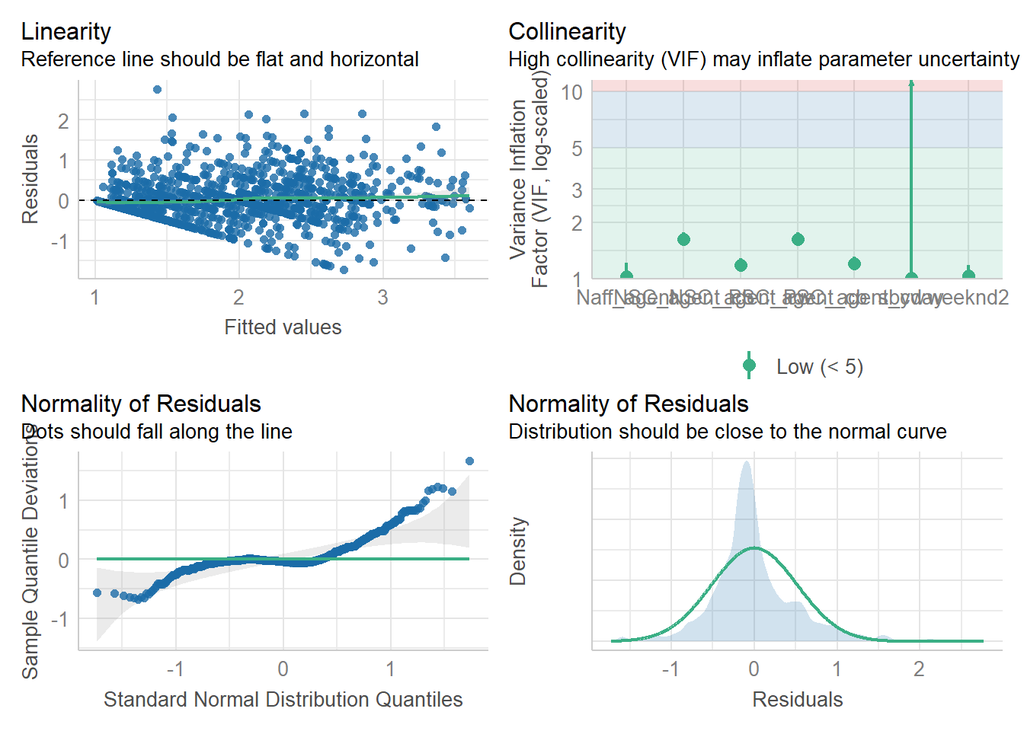

```r
negaff_agent_lagged_rep <- full_report(negaff_agent_lagged,order=order_rep)
negaff_agent_lagged_rep
```

|  | Parameter | Coefficient | SE | p | CI_low | CI_high | Effects |
| --- | --- | --- | --- | --- | --- | --- | --- |
| 1 | (Intercept) | 1.44*** | 0.08 | 0.000 | 1.28 | 1.60 | fixed |
| 17 | —WITHIN-PERSON EFFECTS— | NA | NA | NA | NA | NA | NA |
| 3 | PSC_agent_cw | 0.01 | 0.07 | 0.879 | -0.12 | 0.14 | fixed |
| 4 | NSC_agent_cw | -0.01 | 0.09 | 0.942 | -0.19 | 0.18 | fixed |
| 5 | sbyday | 0.01 | 0.00 | 0.144 | 0.00 | 0.01 | fixed |
| 6 | weeknd2 | -0.01 | 0.04 | 0.762 | -0.08 | 0.06 | fixed |
| NA | NA | NA | NA | NA | NA | NA | NA |
| 18 | —BETWEEN-PERSON EFFECTS— | NA | NA | NA | NA | NA | NA |
| 7 | PSC_agent_cb | 0.30 | 0.18 | 0.089 | -0.05 | 0.65 | fixed |
| 8 | NSC_agent_cb | -0.03 | 0.34 | 0.936 | -0.70 | 0.64 | fixed |
| NA.1 | NA | NA | NA | NA | NA | NA | NA |
| NA.2 | NA | NA | NA | NA | NA | NA | NA |
| NA.3 | NA | NA | NA | NA | NA | NA | NA |
| NA.4 | NA | NA | NA | NA | NA | NA | NA |
| 2 | Naff_agent | 0.22*** | 0.03 | 0.000 | 0.17 | 0.28 | fixed |
| NA.5 | NA | NA | NA | NA | NA | NA | NA |
| NA.6 | NA | NA | NA | NA | NA | NA | NA |
| NA.7 | NA | NA | NA | NA | NA | NA | NA |
| 19 | —RANDOM-EFFECTS— | NA | NA | NA | NA | NA | NA |
| 9 | Std.Dev.(Intercept)\|CoupleID | 0.46 | NA | NA | 0.38 | 0.56 | random |
| 10 | Std.Dev.PSC_agent_cw\|CoupleID | 0.30 | NA | NA | 0.18 | 0.51 | random |
| 11 | Std.Dev.NSC_agent_cw\|CoupleID | 0.15 | NA | NA | 0.03 | 0.84 | random |
| 12 | Cor.PSC_agent_cw.(Intercept)\|CoupleID | 0.02 | NA | NA | -0.23 | 0.28 | random |
| 13 | Cor.NSC_agent_cw.(Intercept)\|CoupleID | 0.24 | NA | NA | -0.90 | 0.96 | random |
| 14 | Cor.NSC_agent_cw.PSC_agent_cw\|CoupleID | -0.94 | NA | NA | -1.00 | 0.93 | random |
| 20 | ———MODEL INFO——— | NA | NA | NA | NA | NA | NA |
| 16 | Within-group standard error | 0.55 | NA | NA | 0.52 | 0.57 | random |
| 21 | dispersion | NA | NA | NA | NA | NA | NA |
| 15 | AR1 | NA | NA | NA | NA | NA | random |

```r
# Add to list

all_models[['negaff_agent_lagged_rep']] <- negaff_agent_lagged_rep
```

#### MVPA - Agent

```r
# Base Model (not converging)
mvpa_partner_lagged <- glmmTMB(
    pbwmvpa01_next_day ~
      pbwmvpa01 +
      PSC_agent_cw + NSC_agent_cw +
      sbyday + weeknd2 +
      PSC_agent_cb + NSC_agent_cb +
      pbwwear_cw + pbwwear_cb +
      (1 | CoupleID),
    family = nbinom1,
    data = df,
    control = glmmTMBControl(optimizer = nlminb,
                             optArgs = list(iter.max = 1e4,
                                            eval.max = 1e4))
)
check_singularity(mvpa_partner_lagged)
```

```
## [1] FALSE
```

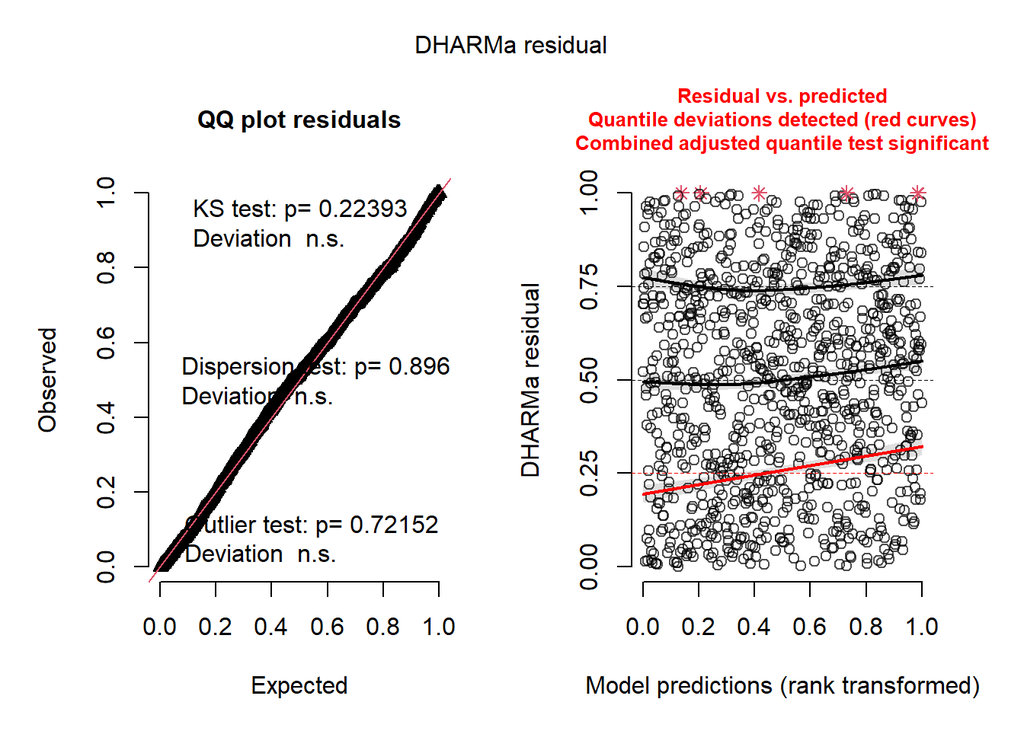

```r
simResids <- simulateResiduals(mvpa_partner_lagged, nSim = 1005)
plot(simResids)
```

```r
mvpa_agent_lagged_rep <- full_report(mvpa_partner_lagged, order= order_rep)
mvpa_agent_lagged_rep
```

|  | Parameter | Coefficient | SE | p | CI_low | CI_high | Effects | Component |
| --- | --- | --- | --- | --- | --- | --- | --- | --- |
| 1 | (Intercept) | 41.42*** | 2.89 | 0.000 | 36.12 | 47.50 | fixed | conditional |
| 13 | —WITHIN-PERSON EFFECTS— | NA | NA | NA | NA | NA | NA | NA |
| 3 | PSC_agent_cw | 1.08 | 0.07 | 0.201 | 0.96 | 1.22 | fixed | conditional |
| 4 | NSC_agent_cw | 0.94 | 0.10 | 0.569 | 0.76 | 1.17 | fixed | conditional |
| 5 | sbyday | 1.00 | 0.01 | 0.538 | 0.99 | 1.01 | fixed | conditional |
| 6 | weeknd2 | 1.10* | 0.05 | 0.040 | 1.00 | 1.20 | fixed | conditional |
| 9 | weartime_cw | 0.99 | 0.01 | 0.542 | 0.97 | 1.02 | fixed | conditional |
| 14 | —BETWEEN-PERSON EFFECTS— | NA | NA | NA | NA | NA | NA | NA |
| 7 | PSC_agent_cb | 0.74 | 0.13 | 0.095 | 0.53 | 1.05 | fixed | conditional |
| 8 | NSC_agent_cb | 1.75 | 0.65 | 0.134 | 0.84 | 3.62 | fixed | conditional |
| 10 | weartime_cb | 0.98 | 0.03 | 0.500 | 0.93 | 1.04 | fixed | conditional |
| NA | NA | NA | NA | NA | NA | NA | NA | NA |
| NA.1 | NA | NA | NA | NA | NA | NA | NA | NA |
| NA.2 | NA | NA | NA | NA | NA | NA | NA | NA |
| NA.3 | NA | NA | NA | NA | NA | NA | NA | NA |
| NA.4 | NA | NA | NA | NA | NA | NA | NA | NA |
| 2 | pbwmvpa01 | 1.00 | 0.00 | 0.109 | 1.00 | 1.00 | fixed | conditional |
| NA.5 | NA | NA | NA | NA | NA | NA | NA | NA |
| 15 | —RANDOM-EFFECTS— | NA | NA | NA | NA | NA | NA | NA |
| 12 | Std.Dev.(Intercept)\|CoupleID | 0.44 | NA | NA | 0.37 | 0.54 | random | conditional |
| NA.6 | NA | NA | NA | NA | NA | NA | NA | NA |
| NA.7 | NA | NA | NA | NA | NA | NA | NA | NA |
| NA.8 | NA | NA | NA | NA | NA | NA | NA | NA |
| NA.9 | NA | NA | NA | NA | NA | NA | NA | NA |
| NA.10 | NA | NA | NA | NA | NA | NA | NA | NA |
| 17 | ———MODEL INFO——— | NA | NA | NA | NA | NA | NA | NA |
| 16 | Within-group standard error | NA | NA | NA | NA | NA | NA | NA |
| 11 | dispersion | 16.99 | NA | NA | 15.30 | 18.86 | fixed | dispersion |
| 18 | AR1 | NA | NA | NA | NA | NA | NA | NA |

```r
# Add to list
all_models[['mvpa_agent_lagged_rep']] <- mvpa_agent_lagged_rep
```

Note, that fixed effects and their CIs have been exponentiated, representing now odds ratios. SE have been scaled. Random effects are still on the log-scale and represent the variability.

# Report everything again side by side for a cleaner appearance.

## FUNCTION TO REPORT EVERYTHING SIDE BY SIDE

```r
report_side_by_side <- function(models, order, model_names) {

  if (length(models) != length(model_names)) {
    stop('Number of models must match number of model names.')
  }

  report_finished <- NULL
  for (i in 1:length(models)) {
    rep <- full_report(models[[i]], order)

    rownames(rep) <- order

    rep$CI <- ifelse(is.na(rep$CI_low), NA,
      paste0('[', rep$CI_low, ', ', rep$CI_high, ']')
    )

    rep <- rep[ , c('Coefficient', 'CI')]


    colnames(rep) <- paste(colnames(rep), model_names[i])
    rep

    #in the first round, we keep the column with the names to the left.
    if (i == 1) {
      rep$Parameter <- rownames(rep)
      rep <- rep[, c(3, 1,2)]
    }


    # Combine
    if (is.null(report_finished)) {
      report_finished <- rep
    } else {
      report_finished <- cbind(report_finished, rep)
    }
  }

  rownames(report_finished) <- NULL

  return(report_finished)
}
```

## Rerport all Lagged Models Side by Side

```r
export_everything <- list()

base_models <- report_side_by_side(
  models = list(
    posaff_agent_lagged, posaff_target_lagged,
    negaff_agent_lagged, negaff_target_lagged,
    mvpa_partner_lagged, mvpa_target_lagged
  ),
  order <- order_rep,
  model_names = list(
    'Posaff Agent Next Day', 'Posaff Target Next Day',
    'Negaff Agent Next Day', 'Negaff Target Next Day',
    'MVPA Agent Next Day', 'MVPA Target Next Day'
  )
)

base_models
```

| Parameter | Coefficient Posaff Agent Next Day | CI Posaff Agent Next Day | Coefficient Posaff Target Next Day | CI Posaff Target Next Day | Coefficient Negaff Agent Next Day | CI Negaff Agent Next Day | Coefficient Negaff Target Next Day | CI Negaff Target Next Day | Coefficient MVPA Agent Next Day | CI MVPA Agent Next Day | Coefficient MVPA Target Next Day | CI MVPA Target Next Day |
| --- | --- | --- | --- | --- | --- | --- | --- | --- | --- | --- | --- | --- |
| (Intercept) | 2.02*** | [1.81, 2.24] | 2.65*** | [2.41, 2.89] | 1.44*** | [1.28, 1.6] | 1.44*** | [1.28, 1.6] | 41.42*** | [36.12, 47.5] | 41.85*** | [36.59, 47.86] |
| —WITHIN-PERSON EFFECTS— | NA | NA | NA | NA | NA | NA | NA | NA | NA | NA | NA | NA |
| PSC_agent_cw | -0.06 | [-0.18, 0.06] | -0.08 | [-0.2, 0.05] | 0.01 | [-0.12, 0.14] | -0.02 | [-0.11, 0.08] | 1.08 | [0.96, 1.22] | 1.04 | [0.93, 1.17] |
| NSC_agent_cw | 0.02 | [-0.18, 0.22] | -0.06 | [-0.28, 0.16] | -0.01 | [-0.19, 0.18] | 0.10 | [-0.06, 0.26] | 0.94 | [0.76, 1.17] | 0.86 | [0.7, 1.05] |
| sbyday | -0.00 | [-0.01, 0] | -0.01** | [-0.02, -0.01] | 0.01 | [0, 0.01] | 0.00 | [0, 0.01] | 1.00 | [0.99, 1.01] | 1.01 | [1, 1.02] |
| weeknd2 | 0.04 | [-0.04, 0.11] | 0.00 | [-0.07, 0.08] | -0.01 | [-0.08, 0.06] | -0.02 | [-0.09, 0.04] | 1.10* | [1, 1.2] | 0.96 | [0.88, 1.04] |
| weartime_cw | NA | NA | NA | NA | NA | NA | NA | NA | 0.99 | [0.97, 1.02] | 0.97* | [0.95, 0.99] |
| —BETWEEN-PERSON EFFECTS— | NA | NA | NA | NA | NA | NA | NA | NA | NA | NA | NA | NA |
| PSC_agent_cb | 0.08 | [-0.16, 0.32] | 0.34* | [0.01, 0.67] | 0.30 | [-0.05, 0.65] | -0.28 | [-0.65, 0.09] | 0.74 | [0.53, 1.05] | 1.04 | [0.74, 1.46] |
| NSC_agent_cb | 0.04 | [-0.42, 0.51] | -0.54 | [-1.18, 0.09] | -0.03 | [-0.7, 0.64] | 0.36 | [-0.35, 1.06] | 1.75 | [0.84, 3.62] | 1.19 | [0.61, 2.33] |
| weartime_cb | NA | NA | NA | NA | NA | NA | NA | NA | 0.98 | [0.93, 1.04] | 1.00 | [0.95, 1.07] |
| —PREVIOUS-DAY OUTCOMES— | NA | NA | NA | NA | NA | NA | NA | NA | NA | NA | NA | NA |
| Paff_agent | 0.48*** | [0.43, 0.53] | NA | NA | NA | NA | NA | NA | NA | NA | NA | NA |
| Paff_target | NA | NA | 0.35*** | [0.29, 0.4] | NA | NA | NA | NA | NA | NA | NA | NA |
| Naff_agent | NA | NA | NA | NA | 0.22*** | [0.17, 0.28] | NA | NA | NA | NA | NA | NA |
| Naff_target | NA | NA | NA | NA | NA | NA | 0.19*** | [0.13, 0.25] | NA | NA | NA | NA |
| pbwmvpa01 | NA | NA | NA | NA | NA | NA | NA | NA | 1.00 | [1, 1] | NA | NA |
| sbwmvpa01 | NA | NA | NA | NA | NA | NA | NA | NA | NA | NA | 1.00 | [1, 1] |
| —RANDOM-EFFECTS— | NA | NA | NA | NA | NA | NA | NA | NA | NA | NA | NA | NA |
| Std.Dev.(Intercept)\|CoupleID | 0.30 | [0.22, 0.43] | 0.43 | [0.33, 0.56] | 0.46 | [0.38, 0.56] | 0.49 | [0.41, 0.59] | 0.44 | [0.37, 0.54] | 0.44 | [0.36, 0.53] |
| Std.Dev.PSC_agent_cw\|CoupleID | NA | NA | 0.24 | [0.12, 0.5] | 0.30 | [0.18, 0.51] | NA | NA | NA | NA | NA | NA |
| Std.Dev.NSC_agent_cw\|CoupleID | NA | NA | 0.19 | [0.03, 1.29] | 0.15 | [0.03, 0.84] | NA | NA | NA | NA | NA | NA |
| Cor.PSC_agent_cw.(Intercept)\|CoupleID | NA | NA | 0.08 | [-0.65, 0.74] | 0.02 | [-0.23, 0.28] | NA | NA | NA | NA | NA | NA |
| Cor.NSC_agent_cw.(Intercept)\|CoupleID | NA | NA | 0.21 | [-0.93, 0.97] | 0.24 | [-0.9, 0.96] | NA | NA | NA | NA | NA | NA |
| Cor.NSC_agent_cw.PSC_agent_cw\|CoupleID | NA | NA | 0.89 | [-1, 1] | -0.94 | [-1, 0.93] | NA | NA | NA | NA | NA | NA |
| ———MODEL INFO——— | NA | NA | NA | NA | NA | NA | NA | NA | NA | NA | NA | NA |
| Within-group standard error | 0.66 | [0.62, 0.7] | 0.55 | [0.53, 0.58] | 0.55 | [0.52, 0.57] | 0.48 | [0.46, 0.5] | NA | NA | NA | NA |
| dispersion | NA | NA | NA | NA | NA | NA | NA | NA | 16.99 | [15.3, 18.86] | 16.46 | [14.83, 18.27] |
| AR1 | -0.25 | [-0.35, -0.15] | -0.07 | [-0.19, 0.05] | NA | NA | NA | NA | NA | NA | NA | NA |

```r
export_everything$Base_Models <- base_models
```

```r
writexl::write_xlsx(export_everything, 'All_models_raw_lagged.xlsx')
```

# References (Packages) and System information

```r
report::report_system()
```

```
## Analyses were conducted using the R Statistical language (version 4.4.1; R Core
## Team, 2024) on Windows 11 x64 (build 22635)
```

```r
report::report_packages()
```

- effectsize (version 0.8.9; Ben-Shachar MS et al., 2020)
- broom.mixed (version 0.2.9.5; Bolker B, Robinson D, 2024)
- glmmTMB (version 1.1.10; Brooks ME et al., 2017)
- Rcpp (version 1.0.13; Eddelbuettel D et al., 2024)
- ggResidpanel (version 0.3.0; Goode K, Rey K, 2019)
- lubridate (version 1.9.3; Grolemund G, Wickham H, 2011)
- Hmisc (version 5.1.3; Harrell Jr F, 2024)
- DHARMa (version 0.4.6; Hartig F, 2022)
- wbCorr (version 0.1.22; Küng P, 2023)
- ggeffects (version 1.7.1; Lüdecke D, 2018)
- parameters (version 0.22.2; Lüdecke D et al., 2020)
- performance (version 0.12.3; Lüdecke D et al., 2021)
- easystats (version 0.7.3; Lüdecke D et al., 2022)
- see (version 0.9.0; Lüdecke D et al., 2021)
- insight (version 0.20.4; Lüdecke D et al., 2019)
- bayestestR (version 0.14.0; Makowski D et al., 2019)
- modelbased (version 0.8.8; Makowski D et al., 2020)
- report (version 0.5.9; Makowski D et al., 2023)
- correlation (version 0.8.5; Makowski D et al., 2022)
- tibble (version 3.2.1; Müller K, Wickham H, 2023)
- datawizard (version 0.12.3; Patil I et al., 2022)
- nlme (version 3.1.164; Pinheiro J et al., 2023)
- R (version 4.4.1; R Core Team, 2024)
- MASS (version 7.3.60.2; Venables WN, Ripley BD, 2002)
- bmlm (version 1.3.15; Vuorre M, Bolger N, 2018)
- ggplot2 (version 3.5.1; Wickham H, 2016)
- forcats (version 1.0.0; Wickham H, 2023)
- stringr (version 1.5.1; Wickham H, 2023)
- tidyverse (version 2.0.0; Wickham H et al., 2019)
- usethis (version 3.0.0; Wickham H et al., 2024)
- dplyr (version 1.1.4; Wickham H et al., 2023)
- purrr (version 1.0.2; Wickham H, Henry L, 2023)
- readr (version 2.1.5; Wickham H et al., 2024)
- devtools (version 2.4.5; Wickham H et al., 2022)
- haven (version 2.5.4; Wickham H et al., 2023)
- scales (version 1.3.0; Wickham H et al., 2023)
- tidyr (version 1.3.1; Wickham H et al., 2024)
- cowplot (version 1.1.3; Wilke C, 2024)

```r
report::cite_packages()
```

- Ben-Shachar MS, Lüdecke D, Makowski D (2020). “effectsize: Estimation of Effect Size Indices and Standardized Parameters.” *Journal of Open Source Software*, *5*(56), 2815. doi:10.21105/joss.02815 https://doi.org/10.21105/joss.02815, https://doi.org/10.21105/joss.02815.
- Bolker B, Robinson D (2024). *broom.mixed: Tidying Methods for Mixed Models*. R package version 0.2.9.5, https://github.com/bbolker/broom.mixed.
- Brooks ME, Kristensen K, van Benthem KJ, Magnusson A, Berg CW, Nielsen A, Skaug HJ, Maechler M, Bolker BM (2017). “glmmTMB Balances Speed and Flexibility Among Packages for Zero-inflated Generalized Linear Mixed Modeling.” *The R Journal*, *9*(2), 378-400. doi:10.32614/RJ-2017-066 https://doi.org/10.32614/RJ-2017-066.
- Eddelbuettel D, Francois R, Allaire J, Ushey K, Kou Q, Russell N, Ucar I, Bates D, Chambers J (2024). *Rcpp: Seamless R and C++ Integration*. R package version 1.0.13, https://dirk.eddelbuettel.com/code/rcpp.html, https://github.com/RcppCore/Rcpp, https://www.rcpp.org. Eddelbuettel D, François R (2011). “Rcpp: Seamless R and C++ Integration.” *Journal of Statistical Software*, *40*(8), 1-18. doi:10.18637/jss.v040.i08 https://doi.org/10.18637/jss.v040.i08. Eddelbuettel D (2013). *Seamless R and C++ Integration with Rcpp*. Springer, New York. doi:10.1007/978-1-4614-6868-4 https://doi.org/10.1007/978-1-4614-6868-4, ISBN 978-1-4614-6867-7. Eddelbuettel D, Balamuta J (2018). “Extending R with C++: A Brief Introduction to Rcpp.” *The American Statistician*, *72*(1), 28-36. doi:10.1080/00031305.2017.1375990 https://doi.org/10.1080/00031305.2017.1375990.
- Goode K, Rey K (2019). *ggResidpanel: Panels and Interactive Versions of Diagnostic Plots using ‘ggplot2’*. R package version 0.3.0, https://goodekat.github.io/ggResidpanel/.
- Grolemund G, Wickham H (2011). “Dates and Times Made Easy with lubridate.” *Journal of Statistical Software*, *40*(3), 1-25. https://www.jstatsoft.org/v40/i03/.
- Harrell Jr F (2024). *Hmisc: Harrell Miscellaneous*. R package version 5.1-3, https://hbiostat.org/R/Hmisc/.
- Hartig F (2022). *DHARMa: Residual Diagnostics for Hierarchical (Multi-Level / Mixed) Regression Models*. R package version 0.4.6, http://florianhartig.github.io/DHARMa/.
- Küng P (2023). *wbCorr: Bivariate Within- and Between-Cluster Correlations*. University of Zürich. R package version 0.1.22. https://github.com/Pascal-Kueng/wbCorr.
- Lüdecke D (2018). “ggeffects: Tidy Data Frames of Marginal Effects from Regression Models.” *Journal of Open Source Software*, *3*(26), 772. doi:10.21105/joss.00772 https://doi.org/10.21105/joss.00772.
- Lüdecke D, Ben-Shachar M, Patil I, Makowski D (2020). “Extracting, Computing and Exploring the Parameters of Statistical Models using R.” *Journal of Open Source Software*, *5*(53), 2445. doi:10.21105/joss.02445 https://doi.org/10.21105/joss.02445.
- Lüdecke D, Ben-Shachar M, Patil I, Waggoner P, Makowski D (2021). “performance: An R Package for Assessment, Comparison and Testing of Statistical Models.” *Journal of Open Source Software*, *6*(60), 3139. doi:10.21105/joss.03139 https://doi.org/10.21105/joss.03139.
- Lüdecke D, Ben-Shachar M, Patil I, Wiernik B, Bacher E, Thériault R, Makowski D (2022). “easystats: Framework for Easy Statistical Modeling, Visualization, and Reporting.” *CRAN*. doi:10.32614/CRAN.package.easystats https://doi.org/10.32614/CRAN.package.easystats, R package, https://easystats.github.io/easystats/.
- Lüdecke D, Patil I, Ben-Shachar M, Wiernik B, Waggoner P, Makowski D (2021). “see: An R Package for Visualizing Statistical Models.” *Journal of Open Source Software*, *6*(64), 3393. doi:10.21105/joss.03393 https://doi.org/10.21105/joss.03393.
- Lüdecke D, Waggoner P, Makowski D (2019). “insight: A Unified Interface to Access Information from Model Objects in R.” *Journal of Open Source Software*, *4*(38), 1412. doi:10.21105/joss.01412 https://doi.org/10.21105/joss.01412.
- Makowski D, Ben-Shachar M, Lüdecke D (2019). “bayestestR: Describing Effects and their Uncertainty, Existence and Significance within the Bayesian Framework.” *Journal of Open Source Software*, *4*(40), 1541. doi:10.21105/joss.01541 https://doi.org/10.21105/joss.01541, https://joss.theoj.org/papers/10.21105/joss.01541.
- Makowski D, Ben-Shachar M, Patil I, Lüdecke D (2020). “Estimation of Model-Based Predictions, Contrasts and Means.” *CRAN*. https://github.com/easystats/modelbased.
- Makowski D, Lüdecke D, Patil I, Thériault R, Ben-Shachar M, Wiernik B (2023). “Automated Results Reporting as a Practical Tool to Improve Reproducibility and Methodological Best Practices Adoption.” *CRAN*. https://easystats.github.io/report/.
- Makowski D, Wiernik B, Patil I, Lüdecke D, Ben-Shachar M (2022). “correlation: Methods for Correlation Analysis.” Version 0.8.3, https://CRAN.R-project.org/package=correlation. Makowski D, Ben-Shachar M, Patil I, Lüdecke D (2020). “Methods and Algorithms for Correlation Analysis in R.” *Journal of Open Source Software*, *5*(51), 2306. doi:10.21105/joss.02306 https://doi.org/10.21105/joss.02306, https://joss.theoj.org/papers/10.21105/joss.02306.
- Müller K, Wickham H (2023). *tibble: Simple Data Frames*. R package version 3.2.1, https://github.com/tidyverse/tibble, https://tibble.tidyverse.org/.
- Patil I, Makowski D, Ben-Shachar M, Wiernik B, Bacher E, Lüdecke D (2022). “datawizard: An R Package for Easy Data Preparation and Statistical Transformations.” *Journal of Open Source Software*, *7*(78), 4684. doi:10.21105/joss.04684 https://doi.org/10.21105/joss.04684.
- Pinheiro J, Bates D, R Core Team (2023). *nlme: Linear and Nonlinear Mixed Effects Models*. R package version 3.1-164, https://CRAN.R-project.org/package=nlme. Pinheiro JC, Bates DM (2000). *Mixed-Effects Models in S and S-PLUS*. Springer, New York. doi:10.1007/b98882 https://doi.org/10.1007/b98882.
- R Core Team (2024). *R: A Language and Environment for Statistical Computing*. R Foundation for Statistical Computing, Vienna, Austria. https://www.R-project.org/.
- Venables WN, Ripley BD (2002). *Modern Applied Statistics with S*, Fourth edition. Springer, New York. ISBN 0-387-95457-0, https://www.stats.ox.ac.uk/pub/MASS4/.
- Vuorre M, Bolger N (2018). “Within-subject mediation analysis for experimental data in cognitive psychology and neuroscience.” *Behavior Research Methods*. doi:10.3758/s13428-017-0980-9 https://doi.org/10.3758/s13428-017-0980-9. Vuorre M (2023). *bmlm: Bayesian Multilevel Mediation*. R package version 1.3.15, https://CRAN.R-project.org/package=bmlm.
- Wickham H (2016). *ggplot2: Elegant Graphics for Data Analysis*. Springer-Verlag New York. ISBN 978-3-319-24277-4, https://ggplot2.tidyverse.org.
- Wickham H (2023). *forcats: Tools for Working with Categorical Variables (Factors)*. R package version 1.0.0, https://github.com/tidyverse/forcats, https://forcats.tidyverse.org/.
- Wickham H (2023). *stringr: Simple, Consistent Wrappers for Common String Operations*. R package version 1.5.1, https://github.com/tidyverse/stringr, https://stringr.tidyverse.org.
- Wickham H, Averick M, Bryan J, Chang W, McGowan LD, François R, Grolemund G, Hayes A, Henry L, Hester J, Kuhn M, Pedersen TL, Miller E, Bache SM, Müller K, Ooms J, Robinson D, Seidel DP, Spinu V, Takahashi K, Vaughan D, Wilke C, Woo K, Yutani H (2019). “Welcome to the tidyverse.” *Journal of Open Source Software*, *4*(43), 1686. doi:10.21105/joss.01686 https://doi.org/10.21105/joss.01686.
- Wickham H, Bryan J, Barrett M, Teucher A (2024). *usethis: Automate Package and Project Setup*. R package version 3.0.0, https://github.com/r-lib/usethis, https://usethis.r-lib.org.
- Wickham H, François R, Henry L, Müller K, Vaughan D (2023). *dplyr: A Grammar of Data Manipulation*. R package version 1.1.4, https://github.com/tidyverse/dplyr, https://dplyr.tidyverse.org.
- Wickham H, Henry L (2023). *purrr: Functional Programming Tools*. R package version 1.0.2, https://github.com/tidyverse/purrr, https://purrr.tidyverse.org/.
- Wickham H, Hester J, Bryan J (2024). *readr: Read Rectangular Text Data*. R package version 2.1.5, https://github.com/tidyverse/readr, https://readr.tidyverse.org.
- Wickham H, Hester J, Chang W, Bryan J (2022). *devtools: Tools to Make Developing R Packages Easier*. R package version 2.4.5, https://github.com/r-lib/devtools, https://devtools.r-lib.org/.
- Wickham H, Miller E, Smith D (2023). *haven: Import and Export ‘SPSS’, ‘Stata’ and ‘SAS’ Files*. R package version 2.5.4, https://github.com/tidyverse/haven, https://github.com/WizardMac/ReadStat, https://haven.tidyverse.org.
- Wickham H, Pedersen T, Seidel D (2023). *scales: Scale Functions for Visualization*. R package version 1.3.0, https://github.com/r-lib/scales, https://scales.r-lib.org.
- Wickham H, Vaughan D, Girlich M (2024). *tidyr: Tidy Messy Data*. R package version 1.3.1, https://github.com/tidyverse/tidyr, https://tidyr.tidyverse.org.
- Wilke C (2024). *cowplot: Streamlined Plot Theme and Plot Annotations for ‘ggplot2’*. R package version 1.1.3, https://wilkelab.org/cowplot/.